# act_report

## Report: act_report

- Create a **250-word-minimum written report** called "act_report.pdf" or "act_report.html" that communicates the insights and displays the visualization(s) produced from your wrangled data. This is to be framed as an external document, like a blog post or magazine article, for example.

The original three datasets were cleaned by addressing the quality and tidiness issues. All the datasets have been combined into one dataframe and stored into a twitter_master_archive.csv file.

The datataset was then explored to understand what kind of tweets were most tweeted, retweeted, and favorited.

The dataset contains 1897 records with a number of charactersitics. Many of the characteristics were from original source data and few additional dervied columns.Below is a brief description of characteristics:

tweet_id is the unique ID that identifies the original tweet

tweet_timestamp is the timestamp of original tweet

rating_numerator is the rating numerator

rating_denominator is the rating denominator

stage is the dog stage

jpg_url is the url for the image

img_num is the number of images in the original tweet

p1 is the first prediction of dog breed

p1_conf is the confidence of first prediction

p1_dog is whether the first prediction is a dog (True/False)

p2 is the second prediction of dog breed

p2_conf is the confidence of second prediction

p2_dog is whether the second prediction is a dog (True/False)

p3 is the third prediction of dog breed

p3_conf is the confidence of third prediction

p3_dog is whether the third prediction is a dog (True/False)

retweet_count is the number of times the original tweet has been retweeted

favorite_count is the number of times the original tweet has been favorited

lang is the language of the original tweet

new_source is the derived source from the original dataset

date_time is date_time of original tweet

day_of_week is weekday of original tweet

rating_ratio is the calculation rating numerator/rating denominator

p_all_dogs is a True/False indicator whether all predictions (p1,p2,p3) are dogs

Below insights were observed in the data after the data was gathered, assessed, and cleaned.

#### Insight #1: Most original tweets originated from Twitter from iPhone

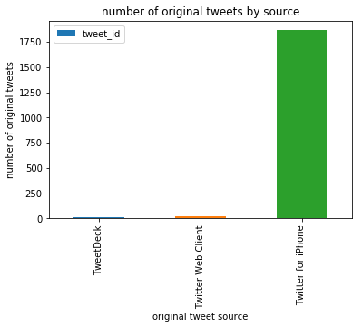

While there are two other sources from whether the original tweets were done. Majority of the tweets were done from Twitter for iPhone.

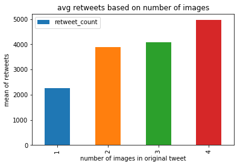

It can be observed from above visual that the number of retweets per original tweet increases by the number of images in the tweet.

#### Insight #3: Tweets on Sunday and Monday have the best rating ratio

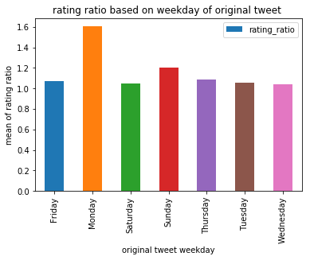

From above visual we can observe that the rating ratio is more or less same on all weekdays, eccept on Sunday and Monday.

#### Insight #4: Images where all the predictions are dogs have the higher chance of tweet being favorited

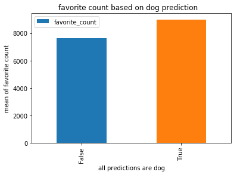

Tweets where all the predictions (p1,p2,p3) are dogs have the most chance of being favorited.

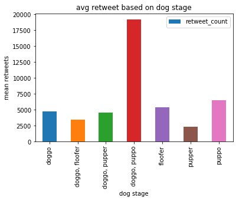

Original tweets with a mention of doggo and puppo have generated the highest number of retweets.